# Introduction

## **What is the Ocean Health Index?**

> The Index is the first assessment framework that provides a common platform for scientifically combining and comparing key elements from all dimensions of the ocean to measure how sustainably people are using the oceans.

The Ocean Health Index (OHI) measures how sustainably the world is interacting with its oceans. It offers the necessary metrics to find the right balance of priorities to ensure that oceans can continue to sustainably deliver their diverse range of benefits and services to people now and in the future. The framework itself is structured around clearly defined **goals** coupled with findings of how the **likely future state** is affected by the social and ecological **pressures** and **resilience** that influence ocean health. The scores are calculated using the best available science, data, and indicators that can be applied to the geographic scale. Scores reflect how well coastal regions are using their ocean benefits in a sustainable way, where a score of 100 means that the evaluated system achieved its defined target, and a score of 0 mean no benefits were achieved or they were achieved in an unsustainable manner.

As a composite index, the Ocean Health Index integrates the results across disciplines and sectors and expresses them through broadly-held public goals:

- **Food Provision** from sustainably harvested or cultured fish stocks
- **Artisanal Fishing Opportunities** for local communities to engage in sustainable practices
- **Natural Products** that are sustainably extracted from the ocean
- **Carbon Storage** in coastal habitats
- **Coastal Protection** from inundation and erosion
- **Sense of Place** from culturally valued iconic species, habitats, and landscapes
- **Livelihoods and Economies** from coastal and ocean-dependent communities
- **Tourism and Recreation** opportunities
- **Clean Waters** and beaches for aesthetic and health values
- **Biodiversity** of species and habitats

## The Benefits of OHI+

The Index is a highly tailorable approach ready to meet the needs and priorities of those who wish to use the ocean sustainably. It is now being expressed through independent Ocean Health Index+ (OHI+) assessments. The OHI+ framework is repeatable, transparent, quantitative, and goal-driven, and the inputs to the OH+ assessments use the same overarching framework while consisting of data and indicators specifically relevant to the local context. Repeated assessments are valuable because they can be used to tack and monitor the progress of ocean health through time. Even a first effort OHI+ is valuable because it establishes a baseline against which to monitor change. Such a flexible framework allows OHI+ assessments to adapt to local conditions while still being useful for management.

> Outside partners are now using the Index framework to conduct their own independent assessments, called Ocean Health Index+ (OHI+) assessments. OHI+ assessments are local interpretations of the original Global Assessments conducted for the first time in 2012 (Halpern *et al.* 2012). The methods have improved since then, and researchers have changed the goals, models, and data in their assessments in an ever-evolving process that characterizes the Index.

The Index is the first assessment tool that provides a common platform for scientifically combining and comparing key elements from all dimensions of the oceans health — biological, physical, economic, and social – to measure how sustainably people are using the ocean. By allowing for a comprehensive and integrated view of marine systems as a way to understand the trade-offs and synergies among these goals, the Index represents a significant advance over conventional single-sector approaches to assessing sustainability as communicated through other kinds of index efforts.

The OHI supports the growing need for marine management to establish comprehensive objectives that maximize the ocean-derived benefits delivered to people while at the same time keeping oceans healthy. As a management tool, the Index can inform decision-making by helping stakeholders identify geographic and thematic priorities for management, which increases the cost-effectiveness of actions taken. At the same time, it addresses the desire for policymakers to increase environmental performance in the face of budget constraints for natural resource conservation, and galvanizes efforts towards ecosystem-based management.

## The Process of OHI+

> TIP: The amount of time required to do an OHI+ Assessment will vary.

The OHI+ process consists of four distinct phases. In the first phase, you will learn about the OHI and understand the philosophy behind it and the motivation for conducting your study. In the second phase, you will actively plan to conduct an OHI+ Assessment. In the third phase, you will engage with the science of finding the data, preparing the goal models, and taking the necessary steps to learn the software and produce the results. In the final phase, you will communicate the results of your OHI+ Assessment in order to inform stakeholders who will use its findings.

- **Phase 1:** **Learn** about the OHI
- **Phase 2:** **Plan** an OHI+ Assessment
- **Phase 3:** **Conduct** the OH+ Assessment
- **Phase 4:** **Communicate** and Inform

[figure not shown]

When conducting an assessment, is it useful to use our timeline as a guide, knowing that the amount of time required to do an assessment will vary. It is important to keep in mind that the process of conducting the assessment requires collaboration and iteration among your team to arrive at the best results possible. The process of conducting an assessment is a scientific one and good documentation to track the decision-making along the way will support the validity of the results.

## Outcomes of OHI+

Goal scores are calculated for each region separately and then combined to produce an overall Index score for the region. Index scores are combined using an area-weighted average to produce the Index score for the overall study area.

[figure not shown]

Scores can then be visualized to communicate the results to stakeholders. For example, the **flower plot** shown in the figure demonstrates a useful way to represent OHI scores. Goal or sub-goal scores are shown around the outside of the plot. The length of each 'petal' represents the goal score, while the width of each petal represents the relative weighting of the goal or sub-goal. Sub-goals are weighted equally by default, as shown here, but can change depending on the regional context.

Clear communication and transparency of the process are fundamental to the Ocean Health Index overall.

- For more information, visit: http://ohi-science.org.

# Phase One: Learn about the Ocean Health Index

> **Phase One** is your first step to conducting an Ocean Health Index assessment. You should learn about the goals of the OHI and understand how it can adapt to your management strategy. You should understand and engage with planning the Index before following to the next Phase.

This section describes the parts of the Ocean Health Index, as well as the philosophy behind all goals and models in the Global Assessments. The recommended process and criteria presented in this section are also presented to offer a systematic approach on how to leverage existing efforts with the Index. The way information is incorporated into the assessment depends on what is most appropriate for your area, which requires considering local conditions and capacities. Knowing the scope of the Index will help you understand how it can scale to fit your needs given your resources.

## **What is the Ocean Health Index?**

The Ocean Health Index scores important **Goals** of ocean health. The Ocean Health Index defines a healthy ocean as one that can sustainably deliver a range of benefits to people now and in the future, while not compromising the state of the oceans and coasts. A healthy ocean in this definition, however, is not necessarily a pristine ocean, although the Index allows for pristine systems as well as sustainably used systems to score highly. In fewer words, the OHI is about balancing priorities.

Scores reflect how well coastal regions optimize their potential ocean benefits and services in a sustainable way. A score of 100 means that the evaluated system achieved its defined target for that goal and is sustainably delivering all of the specified benefits and is likely to continue doing so in the near future. A score of 0 means that global data were available, but that the country either did not achieve any of the available benefits or that the benefits it did obtain were gained in an unsustainable manner.

Because the Index compares scores against the available data within the scope of a given study area, it presents a highly tailorable framework and can match an assessment's geographic scope. It is a structured approach, but the structure may change appropriately with each new interpretation.

> A flexible framework such as the OHI allows assessments to adapt to local context while still being broadly comparable across regions.

The OHI framework is distinct from the organization of the data that go into it. The framework itself is structured around defined ocean-derived **goals** coupled with findings of the **likely future state**, **pressures** and **resilience**. The inputs to the framework consist of the data and indicators used in the assessment and the goal models developed based the local context. In this way, the scores are calculated using the best available data and indicators at the scale of the assessment.

> Outside partners are now using the OHI framework to conduct their own independent assessments, called Ocean Health Index+ (OHI+) assessments. OHI+ assessments are interpretations of the original Global Assessments conducted for the first time in 2012 (Halpern *et al.* 2012). The methods have improved since then, and researchers have changed the goals, models, and data in their assessments in an ever-evolving process that characterizes the Index.

If you are conducting an independent assessment, this **Conceptual Guide** will help you understand the reasoning behind the framework, and will allow you to prepare to make use of local information to get the best results possible.

The benefits provided by the ocean have been measured through these broadly held public goals which are applicable across all geographies:

- **Food provision** from sustainably harvested or cultured stocks
- **Artisanal opportunities** for local communities from sustainable practices
- **Natural products**, including pharmaceuticals and decorative materials, that are sustainably extracted
- **Carbon storage** in coastal habitats
- **Coastal protection** from inundation and erosion
- **Sense of place** from culturally valued iconic species, habitats, and landscapes
- **Livelihoods and economies** from coastal and ocean-dependent communities
- **Tourism and recreation** opportunities
- **Clean waters** and beaches for aesthetic and health values
- **Biodiversity** of species and habitats

## **Understand the scales of assessment**

[figure not shown]

### The Global assessment and your OHI+

> Your assessment will be an example of an Ocean Health Index+ (OHI+) assessment.

Your assessment will be an example of an OHI+ assessment. OHI+ assessments are conducted by independent groups such as yours that use the Index framework to measure ocean health in their own regions, countries, states, and communities. Your OHI+ assessment is different from the Global Assessments because they are meant to fit your local context. The purpose of conducting these independent assessments is that they be used by managers in your area to incorporate information and priorities at the spatial scale where policy and management decisions are made.

The Index framework remains consistent at different scales. Whether at the global level, as in the Global Assessments, or at your more local level, the goal scores are calculated at the scale of the reporting unit, or **region**, and scores are then combined using a weighted average to produce the score for the overall area assessed, called the **study area**.

> In the Global Assessments the **study area** is the world and the **regions** assessed are two hundred twenty-one coastal countries or territories, as well as Antartica in another study and the fifteen regions of the High Seas in an even more recent study. Regions are defined by Exclusive Economic Zones. Antarctica, and the high seas (fifteen sub divisions). Global assessments are conducted by a multidisciplinary team of scientists led by the U.S. National Center for Ecological Assessment and Synthesis (NCEAS), Conservation International, and the Seas Around Us Project. These studies are published annually and use models developed using the best existing data available a the global scale to capture each goal philosophy.

#### Comparing Scales of Assessment

> The overarching OHI framework should guide your efforts, but you should determine the data, models, and other inputs that go into it.

It is important to note that the scores form you OHI+ assessment can't be compared directly to the scores from Global Assessments. Your goal choices, goal models, and input data should be different, which means that your methods will be unique to your area. However, you can compare the scores for the same assessment area through time and make truly quantitative comparisons. Understanding this should allow you to be creative as you develop your plans going into your assessment.

> Even in the Global Assessments, the methods are improved every year by increasing goal model robustness, integrating new data, and recalculating the scores with the improved methods both for the current year and, retroactively, for previous years to allow for year-to-year comparisons. The scientific objectivity comes from applying the same methods and reference points to all regions equally, which also allows for valid comparison of performance across countries.

## Overview of the OHI+ WebApp

> In this section, you will get an introduction to the OHI WebApps. When using the WebApp, you can conduct a preliminary assessment and use the built-in functions to compare input layers, output scores, and change data display options. You will return to the WebApp at the end of the OHI+ process when your team has finalized the calculation methods.

OHI+ WebApps will be very useful for all stages of planning your assessment. The WebApp can be used to **Learn** because it allows for exploration of how the Index works–your team and planning partners can learn what data look like, what map regions are being considered, and ultimately, your team will be able to see how all of the information gathered in your OHI+ assessment will come together. For this reason, the WebApps can be used for **Planning** because they are a communication platform for an assessment team, since information is presented in a manner that is accessible to group members of different disciplines and technical capacities. They will also be kept in mind in the **Conduct** phase, as can be used to set data gathering or goal model development priorities for your assessment. In the final **Communicate** phase, the data outputs from your WebApp will be invaluable as you share your assessment’s data and calculated scores once you have finalized and formatted your data and modified goal models.

## How you will use the WebApp

**OHI+ WebApps** are websites created to facilitate independent assessments, and one is available for nearly every coastal nation or territory. The WebApps are available through http://ohi-science.org using a three-letter identifier in the URL. For example, Ecuador’s WebApp (“ECU”) is found at http://ohi-science.org/ecu. When first exploring a WebApp (for example, http://ohi-science.org/ecu), note that it is possible to **translate** the site into any language that Google provides using the pull-down menu at the top. This will help communication among your team and will facilitate collaboration with partners or stakeholders. You can use the OHI+ WebApp to scope out the planning of your assessment in these initial phases. More importantly, however, it will be useful in the **Conduct** phase when you identify your regions and local priorities, and begin preparing your data, and documenting the decisions that are occurring throughout the process.

[figure not shown]

> Each WebApp displays data layers, which are raw data in this case, as well as the calculated OHI scores based on information extracted from global assessments. As such, they do not provide fine-scale resolution of data for each coastal nation or territory: the scores and data on which they are based are a starting point for an assessment to be conducted by an independent group. These data can be used as a default if better data for the region do not exist, but we encourage you to replace them wherever possible.

## **Determine the Need and Purpose of Conducting Your OHI+ Assessment**

> Remember that producing the Index is not the end in itself–the aim is to *achieving improved ocean health.*

OHI+ is applied research, aiming at solving practical problems related to ocean and coastal resource management. One of your first tasks when developing an OHI+ assessment should be to define the purpose of the study and think about how it can complement other or planned efforts of environmental management. Assessments should be conducted with clear research questions in mind–*how will what you are doing help achieve improved ocean health? How will it solve the problems you want to solve?*

One clear way to think about this is in choosing your study area and the regions that will comprise it. Will your regions match the scales of decision-making, will they match biogeography, or will they try to fit both? Will this require new data, or will it require involvement and the collaboration of neighboring countries?

- See [the Baltic Health Index](http://www.su.se/ostersjocentrum/english/baltic-eye/research/baltic-health-index) for an example of regional collaboration.

Once you have a sense of your regions of interest, you should also consider whether other efforts are already underway to manage those areas and whether researchers are active in the area. This could lead to new opportunities for collaboration, and for chances support new data-collection efforts. You should Identify strengths, weaknesses, opportunities, and threats in your area on both the scientific and the policy scale where possible.

> When conducting an OHI+ assessment, remember that the process is just as important as the results.

Defining the end-goals of the study will largely determine how goal models, data gathering, and reference points are developed to maximize the utility of the findings to inform decision-making, and is very important in ensuring a smooth and successful project with OHI+.

##**Why Ten Goals?**

The Index did not set out to have ten goals. The process of reviewing literature and assessing management objectives resulted in ten goals, several with sub-goals that are each assessed separately. Regions in which some goals are not relevant can (and should) be assessed based only on the remaining goals. The Index is flexible to the inclusion of different or additional goals, something we have not yet encountered but is certainly possible.

###Changing Goal Models

Although the Index framework provides guidelines on how to adapt underlying models to available regional data, using simpler models or different proxies when necessary, it cannot prescribe which available regional data sets are preferred, or dictate the most appropriate models to use or choices of reference points, proxy data or goal weights. These decisions require involving local experts within the region to provide opinions and direction towards an outcome most representative of ocean health in the study area.

The Index can also accommodate additional goals if they better reflect what local communities value, although we feel that the ten goals currently defined within the Index are sufficiently broad to capture a vast majority of values. No indicator is exempt from such subjective decisions. The Index’s framework, however, requires one to document and track such assumptions explicitly and thus, contrary to many other existing indices, allows for careful assessment of the sensitivity of results to such decisions.

## **How are the goals weighted?**

The goals are currently weighted equally in OHI calculations. However, in your OHI+ assessment the weighting can be changed depending on your local context. Stakeholders may have differing priorities, but when presented with the portfolio of goals used in the Ocean Health Index, these differences can become less pronounced, as was found in a study by Halpern *et al.* (2013) in *Marine Policy*. This would require good data, of course, such as the information collected through a representatively sample survey.

## **How is the Index calculated?**

For each goal, models are developed to best represent the philosophy of that goal using the best available data at the scale of study. The present status that is calculated individually for each goal forms half of that goal’s score. The other half, called likely future status, is based on three things:

• the **Trend**, which is the average rate of change for status during the most recent five years

• the total **Pressures** that will harm future benefits

• the total **Resilience** actions that can reduce pressures and maintain or raise future benefits (for example treaties, laws, enforcement, habitat protection)

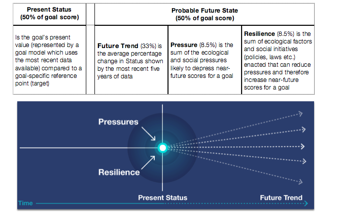

The current status of each goal is determined by comparing the most recent measure of the goal with a goal-specific sustainable **Reference Point**.

The trend is calculated as the slope of the change in status based on recent data. As such, the trend calculation is not trying to predict the future but only to indicate likely condition (sustainability) based on a linear relationship. Pressures and resilience are ultimately important for scores, but they have a smaller contribution to the overall scores because we can only approximate their effects. Individual pressures are ranked for their importance to different goals based on published studies and expert opinion. Resilience actions are the best way to improve a score, because they can reduce pressures, protect ocean habitats and species, improve status, and optimize benefits to people. Status, trend, likely future status, pressures, and resilience are called ‘dimensions’ within the Ocean Health Index framework.

**In the figure below**, likely future state (in yellow) is the result of the current status modified by trend, minus the negative effect of pressures (grey), plus the positive effect of resilience (salmon pink).

[figure not shown]

## **Reference points**

To assess how well a goal is being delivered, it is necessary to identify the target to which it will be compared. This target is called the reference point. In an Ocean Health Index framework, setting the reference point enables the numeric values relevant for each goal to be scaled between zero and one hundred (where one hundred means that the current status is equal to the target reference point, and zero means that it is as far from the target reference point as is possible). Sharing a common range for scores makes all goal scores comparable. The reference point may be a target value at some time in the past, a comparison with some other location (such as the best performing region), a target established by a treaty or other agreement, or—best of all—a target determined by a scientifically-informed input-output relationship (an equation called a **production function**).

It can be advantageous to translate a management goal to a maximization or minimization problem with an objective function so that it is clear exactly how an indicator should be developed to track progress. Indeed, these choices significantly influence the evaluation of a goal’s status. For instance, a sustainable seafood management goal could be measured in terms of yields if the goal is focused on maximizing food provision or in number of jobs if the goal is focused on maximizing social and economic welfare. These two goal framings would lead to the development of different targets in terms of both yields and level of employment. Where necessary, our conceptual framework encourages the reframing of management goals to ensure that the corresponding indicators, and the units in which they are reported, accurately portray the intent of the goal as it is stated.

It is important to understand that setting a reference point is a conscious choice. This choice can be informed by the literature and by expert advice, and can be discussed in terms of costs and benefits. However, ultimately there is no optimum and certainly not only one solution, and this can be very uncomfortable. This makes setting a reference point difficult, but even more important to define explicitly.

## **Understanding Status**

The status component of each goal is captured through a model that represents the philosophy of the goal in a way that produces findings that are most useful to inform decision-making at the scale of your assessment.

The current status of each goal is determined by comparing the most recent measure of the goal with a goal-specific sustainable reference point. For each goal, as well as for many individual data layers, values are rescaled to reference points, or targets, which serve as benchmarks based on SMART principles: Specific (to the management goal), Measurable, Ambition, Realistic, and Time-bound (Samhouri *et al.* 2012; Perrings *et al.* 2010; 2011).

## **Understanding Trend**

The trend is calculated as the slope of the change in status based on recent data. As such, the trend calculation is not trying to predict the future but only to indicate the likely condition based on a linear relationship.

The trend is in most cases the trend in the last five years of data. The exact number of most recent years can change depending on the data sources, but the general idea is that the trend conveys the recent history of the indicator. It does this because the trend is then used to calculate the likely near-term future state and can show a reaction to policy interventions.

## **Understanding Pressures**

A pressure is any kind of stressor on the social or ecological system that is harmful for ocean health.

Pressures can change how goals interact with each other. For example, raising fish in the **Mariculture** sub-goal can cause genetic escapes, which are a pressure on the **Wild-Caught Fisheries** and **Species** sub-goals. The genetic escapes do not affect mariculture itself, however, and have no effect on that particular sub-goal score while they do have a negative effect on the other sub-goal scores.

Pressures are calcuated as the sum of the ecological and social pressures that negatively affect goal scores. The Index framework calculates pressures by first grouping them into five ecological categories (pollution, habitat destruction, fishing pressure, species pollution, and climate change) and one social category. The reason there are categories is to minimize sampling bias, so that no one kind disproportionately influences the score. They are weighted equally in the global assessment, but in your local assessment they can be changed if there is enough information on how to do so.

## **Understanding Resilience**

> Ultimately, it is resilience that will help shape the future of ocean health.

#### Philosophy

A resilience measure can be a law, policy, or a given performance evaluation that speaks to the effectiveness of actions to improve ocean health. Resilience actions are the best way to improve a score for a country, because they can reduce pressures, protect ocean habitats and species, improve status, and optimize benefits to people. There are different categories of resilience, from institutional, to social, to ecological.

> Example: Coral reef organisms have very limited resilience to human-caused pressures. Some individuals and species may tolerate environmental insults better than others, but no natural resilience can reduce such pressures. Protective actions taken by people are a reef’s only ultimate source of resilience. Humans don’t usually take such actions just to preserve a reef for its existence value, but also to safeguard the its flow of benefits to people, including food, ornamental fishes for aquariums, medical products, tourism and others. So from the human perspective, preserving coral reefs is an expression of resilience.

As nation states arose, laws and regulations have steadily evolved to meet their needs. The UN’s main goal was to prevent another world war, but over time it has become the nucleus for international and planetary resilience through programs in peace and security, development, human rights, humanitarian affairs and international law. The UN also organizes treaties such as the Convention on the Law of the Sea (UNCLOS), Convention on Biological Diversity (CBD) and programs such as the Millennium Development Goals and Sustainable Development Goals that aim to end poverty and hunger, build healthy lives and well-being, achieve gender equality and empower women and girls; ensure access to sustainable sources of water, sanitation, energy; reduce inequality; combat climate change; create safe and resilient cities and settlements; and use ocean and land sustainably. Though such engagements are entirely voluntary, most countries participate, and the Ocean Health Index considers such participation in calculating resilience scores.

Physical manifestations of resilience also appeared, such as public works projects for worship, defense, transportation, water, sanitation and many others.

#### Ideal Approach

Ideally, assessments of social resilience would include national-level and as well as local rules and other relevant institutional mechanisms that are meant to safeguard ocean health. The global focus has been on international treaties and indices, so your region should have more localized information. There would also be information as to their effectiveness and enforcement. of more. Information on social norms and community (and other local-scale) institutions (such as tenure or use rights) that influence resource use and management would be useful too.

For each goal the Index measures several aspects of resilience. Ecological integrity is evaluated as the relative condition of assessed species in a given location and goal-specific regulations including laws and other institutional measures that address ecological pressures. Social integrity dis measured as well and escribes the internal processes of a community that affect its resilience. Resilience is then calculated as the sum of the ecological factors and social initiatives (policies, laws, indicators of good governance, etc.) that can positively affect goal scores by reducing or eliminating pressures. This is because resilience in the Index framework acts to reduce pressures in each region. Therefore, resilience measures must not only be directly or indirectly relevant to ocean health, but must be in response to a pressure layer affecting a goal.

#### Keep in Mind

Although resilience really should be judged by the effectiveness of its outcome, this is not possible at the global level. Therefore nations are given advanced credit for signing treaties, e.g., for conserving biodiversity or eliminating trade in endangered species, and for measures of social integrity. The assumption is that results from those beneficial actions and conditions will become visible in following years as increased scores for goal status and trend

## **Interactions: Pressures and Resilience**

Pressures and resilience layers interact with an indicator to increase or decrease its likely future state. The real-world goal of having resilience measures is to lead to an increase in the likely future state, although this can also be achieved through a decrease in the pressures as well. Either way, the most desired outcome for any goal is intended to improve the overall score. This would be most visible through multiple years of engagement with an OHI assessment.

Ecological and social resilience are assessed separately and then combined to determine the goal score. This is usually done with equal weighting, but that could be changed if expert opinion recommended otherwise. Any new resilience measure must be associated with a pressures layer regardless of the weighting, such that, ideally, any pressure on the environment has a countervailing mitigation action. The assessment will use this relationship, and the underlying data, to ultimately convey which is more effective.

**The figure below** shows stressors by category, and the resilience measures meant to 'balance' (or counteract) them for the global assessment. Note that resilience layers are only available for some categories and goals in the Global case, highlighting the importance of data availability for these layers. Also, some resilience measures are goal-specific; that is, they act on certain goals without counteracting pressures. When you have regulations to improve the practices captured in the status specific goals (e.g., sustainable tourism, lower bycatch, etc.), you can include them as resilience measures.

[figure not shown]

Pressures and resilience are ultimately important for scores, but they have a smaller contribution to the overall scores because we can only approximate their effects. Individual pressures are ranked for their importance to different goals based on published studies and expert opinion. Resilience actions are the best way to improve a score, because they can reduce pressures, protect ocean habitats and species, improve status, and optimize benefits to people.

Pressures and resilience are usually summarized across ecological and social pressure categories in order to reveal the influence of any one factor that might be present. The this way, for example, pressures from pollution, habitat destruction, fishing pressure, species pollution, and climate change will have a cumulative impact on the scores.

## **Food Provision**

> The aim of **Food Provision** is to optimize the sustainable level of seafood harvest in your region's waters.

The aim of this goal is to maximize the sustainable harvest of seafood in regional waters from **Wild-Caught Fisheries** and **Mariculture**, or ocean-farmed seafood. Regions are rewarded for maximizing the amount of sustainable seafood provided and they are penalized for unsustainable practices or for under-harvest. Because fisheries and mariculture are separate industries with very different features, each is tracked separately as a unique sub-goal under **Food Provision**. They are then combined after each sub-goal is weighted by the proportion of the total yield it contributes to total food provision.

### **Wild-Caught Fisheries**

> The **Wild-Caught Fisheries** sub-goal describes the amount of wild-caught seafood harvested and its sustainability for human consumption. Higher scores reflect fishing practices with sustainably high yields that avoid excessively high exploitation and do not target threatened existing fish populations.

#### Philosophy

This sub-goal measures the ability to obtain maximal wild harvests without damaging the ocean's ability to continue providing similar quantities of fish for people in the future. The optimal levels are described by Maximum Sustainable Yield (MSY). Higher scores reflect fishing practices with sustainably high yields that avoid excessively high exploitation, or overfishing, and do not target threatened populations. Regions are penalized for resources that are either underfished or overfished because both of these conditions detract from the overall achievement of maximized food provision.

Wild-caught fisheries harvests must remain below levels that would compromise the resource and its future harvest, but the amount of seafood harvested should be maximized within the bounds of sustainability. The reference point is set with a functional relationship. This calculation model aims to assess the amount of wild-caught seafood that can be sustainably harvested, with sustainability defined by multi-species yield, and with penalties assigned for both over- and under-harvesting. This is a departure from traditional conservation goals regarding wild-caught fisheries where under-harvesting is usually not penalized. In other circumstances, penalties are only given for over-harvesting, such as in the case for concerned fisheries managers who use over-harvesting as a way to guide enforcement. In the case of OHI, however, the idea is to assess the delivery of a sustainable benefit or the missed opportunity for one, and therefore any distance from the optimum is a penalty.

This sub-goal can interact with other goals and sub-goals through, for example through the destruction of surrounding habitats that can decrease the productivity of farmed fisheries indirectly.

#### Ideal Approach

Ideally, data for catch size and amount of effort of every commercially- and recreationally-fished species would be available for a place, as well as the functional relationship between the fish population's size in terms of biomass, and fisheries catch effort. This would allow an accurate MSY to be calculated appropriate for the region. Then, fisheries catch and effort information would be used to calculate the present state and MSY would be used to set the reference point. Current status would be calculated using the present state of every species in turn and then combining each species together to get a weighted proportion of the total catch.

#### Keep in Mind

The assessment sustainability, of course, depends on the quality of the underlying stock assessments. Better methods for data-poor stocks had been developed in Global 2013, improving upon those developed for Global 2012. When better data are available and local experts have produced formal stock assessments, better-informed models can be developed, as was done in U.S. West Coast study (2014).

This sub-goal also cannot determine whether the set-points are optimum for other parts of system. For example, this model does not address food security more broadly because this goal does not assess where or by whom the catch is being consumed, and it does not assess nutrition quality either. Potentially, the outcome from assessing the **Food Provision** goal could be used as input if a separate 'food security assessment' were developed.

### **Mariculture**

> **Mariculture** measures the ability to reach the highest levels of seafood gained from far-raised facilities without damaging the ocean's ability to provide fish sustainably now and in the future.

#### Philosophy

Mariculture practices must be sustainable and also maximize the amount of food production that is physically possible and desired by regional governments and those who buy, sell and eat that food. This sub-goal shows whether or not maximal seafood yield from farm-raised facilities is occurring without damaging the ocean’s ability to continue providing fish for people in the future. It is founded on the idea that mariculture practices must not inhibit the future production of seafood in the area.

Higher scores mean that food provisioning is being done in a sustainable manner while not compromising the water quality in the farmed area and not relying on wild populations to feed or replenish the cultivated species. A score of 100 means that a region is sustainably harvesting the greatest amount of farmed seafood possible based on its own maximum potential relative to the conditions of the assessment. As for **Wild-Caught Fisheries**, a low score can indicate one of two things – that species are either being farmed in an unsustainable manner, or that assessed areas are not maximizing the potential to farm in their waters.

#### Ideal Approach

Ideally, information on the spatial area available for mariculture would be available, as well as data on the sustainability of that production. Availability could be determined by social expectations and priorities, not just geographical space. This would mean that data are available for the physical coastal and offshore habitat appropriate for each intended type of mariculture service and that areas have been identified as socially appropriate. At a regional scale, better data should demonstrate any restrictions based on habitat, conflicting uses, and social preferences.

#### Keep in Mind

This approach would not necessarily penalize regions that have less geographic area available for mariculture, because it is relative to what is marked as available. However, places with fewer sheltered bays or lower primary production, for example, could be at a disadvantage compared to places that have more favorable conditions.

The appropriateness of the approach will also vary depending on the geography and what's socially desirable. For instance, in the Global 2012 study, China's ratio of area dedicated to mariculture production relative to area available showed the highest score and therefore became the reference point against which other countries' values were compared. Simply maximizing isn't always desirable, however. The social component is important because mariculture competes for space with many other ocean uses, including other kinds of fishing and tourism activities. This sub-goal reveals linkages among ocean health issues.

> As another example, Global 2012 did not have information about social limitations for how much coastal area could be allotted to mariculture, and therefore it included the entire area of the coastline in the calculation. This assumed that mariculture could be developed everywhere, which isn't always socially desirable.

## **Artisanal Fishing Opportunities**

> The **Artisanal Fishing Opportunties** goal shows whether people with the desire to fish on small scales have the opportunity to do so.

#### Philosophy

It is important to capture the degree to which a region permits or encourages artisanal fishing compared to the demand for such fishing opportunities, and if possible, the sustainability of artisanal fishing practices.

The artisanal fishing opportunities goal measures the opportunities for artisanal fishing rather than the amount of fish caught (covered in the **Food Provision** goal) or the household revenue earned from the activities (covered in the **Livelihoods and Economies** goal). In the Global Assessments, higher scores reflect high potential for the local population to access local ocean resources, regardless of whether or not those people actually do get access. This goal is about economic access, physical access, and access to the fish themselves. Economic access is comprised of needs and costs involved, and physical access is determined by how possible it is for individuals to get to the resource. Access to the fish themselves is a reflection of how robust fish populations are measured ot be.

Damaging practices are sometimes used in artisanal fishing, such as the use of cyanide or dynamite, and these are penalized in the Index calculations. Such practices also lead **Artisanal Fishing Opportunities** to interact in a negative way with other goals.

#### Ideal Approach

Ideally, this goal would include some measure of how easy or hard it is for people to access ocean resources when they need them and a quantified evaluation of the sustainability of harvest of all nearshore stocks used by artisanal fishermen. It will require the creative combination of different kind of data elements.

#### Keep in Mind

This goal reflects only the access people have to coastal resources, not necessarily whether they actually do fish in those waters. In other words, It measures the potential for artisanal fishing whether or not this potential is actually met. This is because this goal specifically tries to estimate whether individuals or households have the access to the sea that they need for their own survival. The status for this goal is estimated as a function of need for artisanal fishing opportunities and whether or not the opportunity is permitted or encouraged institutionally, and whether artisanal fishing could be sustainable.

Keep in mind also that the amount of seafood caught, if reported, is contained within the **Food Provision** or **Natural Products** goals. Meanwhile, any wages or revenue are included instead in the **Livelihoods and Economies** goal. The data for this goal should therefore reflect its unique intention.

## **Natural Products**

> The **Natural Products** goal describes how sustainably people harvest non-food products from the sea.

#### Philosophy

**Natural Products** evaluates the levels of sustainability for all ocean-derived goods that are traded. These include shells, sponges, corals, seaweeds, fish oil, and ornamental fishes, among other things. It does not included products that are consumed for only nutrition, but may in some cases include products that are consumed as medicine. In the Global Assessments, the goal model calculates overall status by weighting the status of sustainable harvest of each extracted marine product by its proportional value relative to other harvested products. Higher scores reflect sustainable extraction of non-food ocean resources with little to no impact on surrounding habitats, marine species, or human well-being.

#### Ideal Approach

Ideally, quantity, value, and a sustainability rating of the harvest method would be available for every marine and coastally-derived natural product within the regions of a study area. This would include a wide range of products, including corals, shells, seaweeds, aquarium fish, mangrove wood, or any non-food marine product that is harvested within a region. The ideal reference point would be derived from a functional relationship of the sustainability of the harvest for each product relative to the amount of product available in the ecosystem, informed by scientific studies.

#### Keep in Mind

This goal does not include non-living items such as oil, gas, and mining products, because these practices are not considered to be sustainable. They are also done at such relatively large scales that including them would essentially make an index for those sectors specifically. This goal also does not include any valuation of things like bioprospecting for medicines through genetic discoveries, which has an unpredictable potential value occurring in the future rather than measurable value now.

The activities that drive this goal can interact with other goals and sub-goals when unsustainable harvesting practices are used. Because so little is known about some of the functions relationships between the amount of natural products taken and the effect of harvest on their quantities in the ecosystem, assumptions often have to be made to set the reference points in the calculations.

## **Carbon Storage**

> **Carbon Storage** describes how much carbon is stored in natural coastal ecosystems that absorb and sequester it in large amounts.

#### Philosophy

**Carbon Storage** evaluates the status of coastal marine habitats with high carbon storage capacity. In this case, “storage” means carbon sequestration. Highly productive coastal wetland ecosystems, like mangroves, salt marshes, and seagrass beds, have substantially larger areal carbon burial rates than terrestrial forests. Coastal habitats therefore play a significant role in mitigating global carbon levels, and the health of these habitats is important because their destruction also releases large quantities of carbon into the atmosphere, damaging the overall health of coupled marine systems and furthering global climate change.

> Though they form less than 2% of the ocean’s surface, coastal ecosystems contribute more to long-term carbon storage and sequestration in sediments than any other ocean ecosystem.

Our focus here is on coastal habitats, so-called “Blue Carbon”, because they have large potential to store carbon without causing acidification, and, contrary to open oceans, they provide a carbon storage service that can be affected by human actions such as conservation, and restoration efforts.

> The Global 2012 assessment focuses on three ecosystems — mangroves, tidal marshes and seagrasses — for their ability to store and sequester carbon in their plants and soils. When destroyed or degraded, these ecosystems not only stop sequestering carbon but can start to release it, and can emit carbon for centuries and contribute to climate change.

#### Ideal Approach

Ideally, to assess the amount of carbon stored in every coastal habitat, information would be available regarding coverage area and some measure of quality. For example, you would have data for both the spatial coverage of a mangrove and know its tree density. Additionally, different weights would be assigned to the habitats based on their relative ability to store carbon. The carbon storage model can incorporate such weights once they are available in a similar way to the methods developed for the coastal protection goal. The reference point for habitat-based goals will likely be a comparison with a historic extent or state; this means that historic data are needed such that current habitat extent data can be compared to them.

> TIP: The relative carbon storage abilities for different habitats is an area of active research.

#### Keep in Mind

Even though the pelagic oceanic plays a large role in the sequestration of anthropogenic carbon, by acting as a large carbon sink, the mechanisms for open ocean carbon storage cannot be managed locally or regionally as there are no practical methods for intervention or manipulation. On top of that, the storage of global carbon in ocean water leads to its acidification, which has many consequences for marine life.

Because they store carbon for less than one hundred years, seaweeds and corals were not included in the **Carbon Storage** goal in the Global Assessments. While the pelagic oceanic carbon sink, consisting of phytoplankton, plays a large role in the sequestration of anthropogenic carbon, the pelagic ocean mechanisms are not amenable to local or regional management intervention. Phytoplankton contribute to carbon fixation when they die and sink to the sea bottom at sufficient depth, because it is effectively out of circulation. However, if those phytoplankton are eaten, the carbon is cycled back into the system and not sequestered.

Something that could potentially be included in the **Carbon Storage** goal in the future is mollusc shells, if they are added to a landfill and not recycled in the sea. So if information on mariculture production and waste disposal are available, this could be an interesting addition to carbon storage at a regional scale.

## **Coastal Protection**

> **Coastal Protection** describes the condition and extent of habitats that protect the coasts against storm waves and flooding. It measures the area they currently cover relative to the area they covered in the recent past.

#### Philosophy

Many habitats, including coral reefs, mangroves, seagrasses, salt marshes, and sea ice, act as natural buffers against storm damage and erosion. By protecting against incoming waves, flooding, and and other erosive factors, these living habitats keep people safe and can help mitigate economic loss of personal and public property, cultural landmarks, and natural resources. The **Coastal Protection** goal assesses the amount of protection provided by marine and coastal habitats by measuring the area they cover now relative to the area they covered in the recent past.

#### Ideal Approach

Ideally, data for all habitats within regions of a study area would be available, as well as information on the value of the land and the vulnerability of inhabitants being protected by these habitats. This would require data for each habitat type at a high spatial resolution as well as a measure of the value of what is protected by the habitats. The reference point for habitat-based goals will likely be a temporal baseline and historic data would be needed such that current habitat and value data can be compared to them.

#### Keep in Mind

The Global studies did not include an assessment of the protection afforded by human-made structures such as jetties and seawalls, because these structures cannot be preserved without maintenance and do not constitute long-term sustainable services. They may also have other undesirable side effects such as the altering of sedimentation rates causing erosion in new and unexpected locations. Although this phenomenon is closely tied to human habitation, it does not account for such things as property values as indicators but rather it focuses on what the habitats actually are and the protection that they provide.

## **Coastal Livelihoods and Economies**

> The **Coastal Livelihoods and Economies** goal rewards productive coastal economies that avoid the loss of ocean-dependent livelihoods while maximizing livelihood quality.

This goal is founded on two sub-goals, **Livelihoods** and **Economies**. **Livelihoods** is comprised of jobs and wages, and **Economies** is comprised of revenues. The two halves of this goal are tracked separately because the number and quality of jobs and the amount of revenue produced are both of considerable interest to stakeholders and governments, and could show very different patterns, such as is the case when high revenue sectors do not necessarily provide large employment opportunities. The goal aims to maintain the number of coastal and ocean-dependent livelihoods (jobs) in a region, and maintain productive coastal economies (revenues), while also maximizing livelihood quality (represented by relative wages).

> This is an area where economic studies are integrated and inform the concept of ocean health.

#### Keep in Mind

Maintaining jobs in this case means not losing jobs–this sub-goal does not give credit for *gaining* jobs in the Global Assessments. It does not attempt to capture aspects of job identity like reputation, desirability, or other social or cultural perspectives associated with different jobs, nor does it account for the impact upon an individual but rather focuses on the aggregate. One can examine the component parts that make up this goal, however, to evaluate individual sectors and infer implications for job identity.

### **Livelihoods**

> The **Livelihoods** sub-goal describes livelihood quantity and quality.

#### Philosophy

This sub-goal evaluates the quantitative and qualitative benefits workers get from the oceans in the form of jobs and wages. In the Global Assessments, the two sub-components are equally important because the number of jobs is a proxy for livelihood quantity, and the per capita average annual wages is a proxy for job quality. Some relevant sectors include tourism, commercial fishing, marine mammal watching, and working at ports and harbors, among others. Jobs and wages produced from marine-related industries are clearly of huge value to many people, and directly benefit those who are employed–they also benefit those who do not directly participate in the industries but rather gain indirectly from the value of community identity, tax revenues, and other indirect economic and social impacts of a stable coastal economy.

#### Ideal Approach

Ideally, this goal would represent and encompass all marine sectors that supply jobs and wages to coastal communities, incorporating information on the sustainability of different sectors and also working conditions and job satisfaction. Job identity would also be an important part of this. Capturing the indirect as well as direct benefits from jobs, wages and revenue from coastal communities and beyond is best; where data do not exist, multipliers derived from the literature can be incorporated into jobs to attempt to capture this. The reference point in this sub-goal will likely be set as a moving window temporal approach, or a spatial comparison.

#### Keep in Mind

It's important to note that the data approaches taken to date in the Global Assessments are imperfect, and do not represent the one way to convey the importance of individual identity with coastal work. The values are shown for the aggregate community and are proxies for quality-of-life of the individual. In further assessments, any new data that may otherwise speak to well-being would represent a useful improvement.

### **Economies**

> The **Economies** sub-goal captures the economic value associated with marine industries using revenue from marine sectors.

#### Philosophy

The **Economies** sub-goal evaluates the revenue generated from marine-based industries. Strong coastal economies are something that people value, and this can be reflected by the GDP generated by these coastal regions both directly and indirectly. The economies sub-goal is composed of a single component, revenue.

#### Ideal Approach

Ideally, economic data would be collected for each coast, and traced from sectors both directly and indirectly related to marine industries. When these data are not available it is possible to use revenue data at a larger scale and adapt them to a coastal area based on population distribution. The reference point in this sub-goal will likely be set as a moving-window temporal approach.

#### Keep in Mind

The definition of a marine-related sector can vary. There are jobs that are directly connected to the marine environment, such as shipping, fishing, longshore workers, but also some that are connected indirectly, such as supplies and supporting industries. The use of multipliers in attempts to capture the indirect revenue generated by jobs more indirectly associated to marine sectors is a well-established method in economics, and is encouraged in this approach.

## **Tourism and Recreation**

> The **Tourism and Recreation** goal captures the value people have for experiencing and taking pleasure in coastal areas.

#### Philosophy

This goal measures the value people have for experiencing and taking pleasure in coastal and ocean areas. Tourism, travel, and recreation are major drivers of thriving coastal communities and they also offer a measure of how much people value ocean systems. By electing to visit a coastal area rather than an inland area, people express their preference for visiting these places over others. Ideally, tourism and recreation could continue indefinitely if it is done in a sustainable manner.

#### Ideal Approach

Ideally there would be data available specifically for employment in coastal tourism industries, however the best data available at a global scale report total number of jobs, not just coastal jobs, within the travel and tourism industries. These data include jobs that are directly connected to the tourism and travel industry, for both leisure and business. This could include accommodation services, food and beverage services, retail trade, transportation services, and cultural, sports and recreational services, and could exclude investment industries and suppliers. There would also be information on how the ocean is used for enjoyment by both local residents and tourists, thereby capturing the full value of touristic and recreational activities.

#### Keep in Mind

**Tourism and Recreation** does not include the revenue or livelihoods that are generated by tourism and recreation; that is captured in the **Livelihoods and Economies** goal. This goal is not about the economic benefits, but instead about the value that people have for experiencing and enjoying coastal areas.

Models will vary greatly depending on data available; there are many ways to potentially measure the delivery of this goal.

> Unfortunately it was not possible to determine the proportion of jobs affiliated with strictly leisure travel in the Global 2013, for example. It was assumed all travel and tourism employment was related to tourism and recreation values. Additionally, it is true that not every tourist stays in a hotel and not everyone staying in a hotel is a tourist.

## **Sense of Place**

> The **Sense of Place** goal aims to capture the aspects of coastal and marine systems that people value as part of their cultural identity and connectedness to the marine environment.

The **Sense of Place** definition includes people living near the ocean and those who live far from it and still derive a sense of identity or value from knowing particular places or species exist. Since few groups, communities, or states have explicitly described the attributes of the coastal and ocean environments that have special cultural meaning to them, the Index assesses how well this goal is being delivered through the conditions of two sub-goals, **Iconic Species** and **Lasting Special Places**. The overall goal score is then the arithmetic mean of the two sub-goal scores.

### **Iconic Species**

> The **Iconic Species** sub-goal assesses the threat to species that are important to a region.

#### Philosophy

**Iconic Species** are defined as those that are relevant to local cultural identity. The intent of the sub-goal is to focus on those species widely perceived as iconic within a region, and iconic from a cultural or existence value. This is in contrast to an economic or extractive reason for valuing the species. Iconic species symbolize the cultural, spiritual, and aesthetic benefits that people hold for a region, often bringing intangible benefits to coastal communities and beyond.

They can be identified through activities such as fishing, hunting, or commerce; through local ethnic or religious practices; through existence value; and through locally-recognized aesthetic value. This can even include, for example, touristic attractions and iconic species as defined by their repeated representation in local art.

#### Ideal Approach

Ideally, data would be available on all species that are important to coastal communities, and then a separate assessment would judge the condition of each of the populations. It would ideally be possible to find an officially-sanctioned list, or a list from a trusted source, of the iconic species for an area.

#### Keep in Mind

The type of valuation carried out here stands in contrast to simply an economic or extractive reason for valuing the species. Even so, because almost any species can be iconic to to different groups or individuals, and defining which species are culturally iconic can be challenging. Information can sometimes be found from local customs and experts, oral tradition, sociological or anthropological literature, journalism, and regional studies.

### **Lasting Special Places**

> The **Lasting Special Places** sub-goal captures the conservation status of geographic locations that hold significant aesthetic, spiritual, cultural, recreational, or existence value for people.

#### Philosophy

Th **Lasting Special Places** sub-goal focuses on those geographic locations that hold particular value for aesthetic, spiritual, cultural, recreational or existence reasons. It is different from simply quantifying protected areas because it attempts to contain the value of sustainability for human interaction. Well-maintained and protected lasting special places provide intangible but significant resources that help sustain and may also generate economic opportunities and help to sustain coastal communities, but those are captured in other goals.

> In the Global Assessments, the scores for this sub-goal are calculated based upon two assumptions: that all regions have roughly the same percentage of their coastal areas (outward to 3 nm and inland to 1 km from the shore) that qualify as lasting special places, and that the regions with the most protected areas are the closest to achieving their region-specific target.

#### Ideal Approach

Ideally, a list of all the places that people within a region consider special could be found or developed, along with an assessment of what percent of and how well those areas are protected. First-hand information could be gathered through surveys or some similar approach.

#### Keep in Mind

This goal is hard to define in terms of data. Other goals capture the economic benefits derived from **Lasting Special Places**, as well as biodiversity. This goal assesses the human-use and assumes sustainability through aesthetic, cultural, and other kinds of engagement.

## **Clean Waters**

> The **Clean Waters** goal captures the degree to which local waters are unpolluted by natural and human-made causes.

#### Ideal Approach

Ideally, data would be available and combined from many different categories of marine pollution to best capture the factors that can cause waters to become unsuitable for recreation or other purposes. There would be data available across various classes of contaminants, including organic pollutants, inorganic pollutants, metals, oils, turbidity, and trash. Having good data from each of the desired categories, such as those culled from a repeated effort at monitoring the conditions of the coasts, would be ideal. For the reference point, a functional relationship would be best for setting hard use limits.

#### Keep in Mind

Due to data constraints, the models described in the Global Assessments mostly used information on pollutant inputs from point sources. If in-situ measurements of water and biological uptake from organisms are available, these types of information would be preferred. Particularly, information on eutrophication anomalies, anoxic regions, and toxic blooms, would be preferable to the nutrient inputs used in previous assessment, which are really just proxies for the better data.

> In the Global Assessments, it was not possible to assess specific toxic chemicals at the global scale; however regional case studies often might have data available for the quantities and toxicity of a range of chemicals put into watersheds and coastal waters. In addition, where possible and relevant, we recommend including additional component that could not be covered in the models presented in the Global due to data constraints, such as altered sedimentation or turbidity.

## **Biodiversity**

> The **Biodiversity** goal captures the conservation status of marine species.

**Biodiversity** measures the condition of species and key habitats that support species richness and diversity. It is is measured through two sub-goals: **Species** and **Habitats**. Species were assessed because they are what one typically thinks of in relation to biodiversity, and people value biodiversity in particular for its existence value. But because only a small proportion of marine species worldwide have been mapped and scientifically assessed, habitats are used a proxy for the condition of the broad number of species that depend on them. A simple average of these two sub-goal scores produces the **Biodiversity** goal score in the Global Assessment.

### **Species**

> The **Species** sub-goal aims to estimate how successfully the richness and variety of marine life is being maintained.

#### Philosophy

The **Species** sub-goal aims to estimate how successfully the richness and variety of marine life is being maintained. People value the species that comprise marine biodiversity for their existence value as well as their contributions to resilient ecosystem structure and function. The risk of species extinction generates great emotional and moral concern for many as well.

#### Ideal Approach

Ideally, data would be available on the number of species in each region of a study area, along with their habitat ranges, and assessments of their population size or conservation status. The conservations status should be undertaken by a trusted authority, such as the International Union for the Conservation of Nature.

> China, for example, has its own equivalent to the IUCN **Red List** of Endangered Species. If a country has conducted its own species surveys and assigned categories of risk, that information may be more useful than the global data not specialized to the local context.

#### Keep in Mind

The **Species** sub-goal is conceptually equal to iconic species, but it includes all species that are scientifically assessed. This will limit your data to those species that have this kind of information. The species data layers in the Global Assessments included the amount of area where each species is present, so that species that inhabit a greater area have a greater weight in the calculations than those with a smaller range. This was different from the **Iconic Species** approach.

Note that **Biodiversity** can also play a supporting role in **Food Provision** and sustainability generally, and is therefore also included in the resilience dimensions of other public goals.

### **Habitats**

> The **Habitats** sub-goal measures the condition of habitats that are important for supporting a wide array of species diversity.

#### Philosophy

This sub-goal measures some of the habitats that are particularly important in supporting large numbers of marine species. Habitats are areas where animals can thrive and bring further positive benefits–whether for existence value or for other enjoyment. The amount of area needed to ensure biodiversity varies with habitat type and animal size, so therefore this is an indirect approach to representing the status of biodiversity.

> TIP: It would be possible to remove this sub-goal, in fact, if perfect data on assessed species were available, because this sub-goal is a proxy for the other half of the **Biodiversity** goal.

#### Ideal Approach

Ideally, information on the extent and condition of every single habitat type would be available through time. The reference point for habitat-based goals will likely be temporal, meaning means that historic data are needed such that current habitat and value data can be compared to historic data.

#### Keep in Mind

> TIP: Consider approaching this goal with **Carbon Storage** and other spatially explicitly goals, when conducting your assessment in Phase Three.

# Phase Two: Plan an OHI Assessment

This document contains the steps of the second of four phases in conducting an assessment. In this section you will be guided through how to:

> Understand the Requirements of Conducting an Assessment
> - Funding
> - Data Availability

> Planning and Partnering with Decision Makers
> - Who Should Be Involved?
> - Conducting a Stakeholder Analysis
> - Introducing the OHI+ Concept to Key Stakeholders

> Strategic Planning
> - Considerations for Joint Planning
> - Vision
> - Objectives
> - Spatial Scale
> - Strategy
> - Task Timeline
> - Costs and Financial Planning
> - Adaptive Management

##**Understand the Requirements for Conducting an OHI Assessment**

Before you begin actually running your assessment, it is crucial to have a full understanding of what will be required to complete a successful assessment. Running an assessment is a labor intensive process that requires collaboration, communication, funding, dedication and, perhaps most importantly, data.

It is imperative to ensure that you have all of these components before starting your assessment.

Completing a stakeholder analysis as well as a leading Working Group will greatly enhance your opportunities for and abilities to collaborate and communicate. It will also give you access to a larger pool of resources.

Procuring funding and creating a budget that is informed by the task timeline will also aid in smart spending and decrease the likelihood that funding will run out before the process is completed. For more information on procuring funding and to see how assessments have been funded in the past, click here

The availability of local data is perhaps the single most important requirement for conducting an OHI+ assessment.

Index scores are a reflection of data quality, and thus, accessing the best data available is of the highest importance. Data from existing environmental, social, and economic indicators may be used. All data will be rescaled to specific reference points (targets) before being combined therefore setting these reference points at the appropriate scale is a fundamental component of any assessment. This requires the interpretation of the philosophy of each Index goal and sub-goal using the best available data and indicators. Click here to see a list of data required to conduct an assessment.

###**Funding**

Generally funding comes from the public sector, but other assessments have developed proposals that have been funded by the private sector.

In some other cases foundations, research labs and academic institutions provide the funding. More specifics on funding will be included under the Strategic Planning section.

## **Assembling a Team**

The success of your OHI+ assessment will depend on the effectiveness of your team. While every assessment will be done differently–it is always done according to local needs, resources, and priorities–we do have some guidance on suggested ways to go about assembling a team.

It is very important to have, for example, contacts who are experts in the following:

- R analysis
- Fisheries models
- Geospatial analyst (GIS or open-source software)
- Other Subject-Matter Experts to inform goal model decisions

- For more information, see the **Task Timeline** in the **Conceptual Guide**

#### Case Study: The Baltic Health Index

One approach, for example, that has been very successful is to spread the goal model development across different team members. In the Baltic Health Index assessment, for example, each chosen goal has been assigned to a different “Goalkeeper,” who is responsible for their technical team's development of goal models, data, as well as the appropriate stakeholder engagement. There is also a separate “Pressures” point-person and a separate “Resilience” point-person, which has proven to be an effective approach–since pressures and resilience are cross- cutting across goals, and the data for them are so important. The larger effort is then coordinated by another team member, who ensures that the goalkeepers are working toward the desired objective.

Effective assessments are carefully planned and require adequate project leadership and vision. Due to the multidisciplinary nature of the Index, assessments often count with participation of various stakeholder groups. Nevertheless, we recommend a key agency or group assumes the leadership of the assessment to ensure proper planning, development, and engagement throughout the assessment.

###**Data Requirements**

Time-series data are needed for the four components of each goal: Status, future trend, pressures, and resilience.

Data required for status and trend:

- Fisheries mariculture harvest
- Natural products harvest
- Need and ability for small-scale fishing
- Coastal habitats extend and condition
- Employment, wages, and revenue of coastal industries
- Species extinction risks and protection of special places
- Tourism and recreation information
- Water pollutants

Data required for pressures:

- Ecological pressures
  - Pollution
  - Habitat destruction
  - Species threats
  - Fishing impacts
  - Climate change
  - Social pressures
- Governance indicators

Data required for resilience

- Ecological resilience
- Regulatory framework
- Ecological integrity
- Social resilience
- Social integrity
- Governance indicators

##**Planning and Partnering with Decision Makers**

> “The Index offers a tool to engage stakeholders and decision-makers in difficult but necessary discussions, while also helping agencies fulfill their mandates” (Halpern *et al.* 2014)

For your assessment, appropriate conditions and resources will include scientific capacity, government actions (policies, barriers to action, regulatory frameworks and transparency), and civil engagement, all of which create an environment conducive to effectively conducting the assessment.

Although the Index assessments can be produced without the input of non-scientific groups (policy, civil society, etc.), *multi-stakeholder collaborative planning and decision-making are more likely to yield integrated management efforts* focusing on coordinating multi-sector activities, assessing cumulative impacts and trade-offs, and maximizing sustainable productivity. Therefore, the steps we present here propose establishing a strong multi-disciplinary management and leadership framework, and focus on developing a strong strategic plan that can guide the entire process.

Achieving healthy oceans (i.e., reaching the targets established) will require using information produced from the assessment to adopt management actions and enact policies that gradually improve ocean conditions across multiple ocean goals.

Successful assessments require leadership to help set targets and get buy-ins from various interested parties. The assessment should be an element of a larger strategy to improve ocean health and in no case should it be the sole strategy for improving ocean health.

###**Who Should Be Involved?**

The assessment process will require a dedicated and interested group of individuals to lead the initiative. This core team, tasked with detailing the process, may include managers, government officials, community members, nongovernmental representatives, and others.

Stakeholder participation may vary greatly depending on the purpose of the assessment and the unique characteristics of the regions chosen for the study. Prior initiatives demonstrate that enduring success is more likely when stakeholders and communities are actively involved throughout the planning process.

The process of implementing the tool will require scientists and leaders to make politically sensitive decisions across multiple social, political and economic dimensions. We recommend creating a Working Group of individuals who are able to commit important time to the processes, and have the authority necessary to represent their organizations. A Technical Working Group can support the calculation of the goal scores and esablish a scientific nature to ensure validity.

Ensuring continuous transparency and participatory opportunities is essential to guaranteeing that the findings will be widely accepted and validated. Although a participatory process is highly encouraged, there should be a balance between stakeholder participation and keeping the process moving along a pre-established timeline. It is very important to create clear guidelines for participation, and assign specific roles and responsibilities to the team members directly involved in the process.

Participant stakeholders could include, but are not limited to, the following:

**Scientific/Academic institutions**

- University research centers
- Government statistics departments

**Government**

- Ministry/Department of:
  - Environment
  - Production
  - Planning
  - Fisheries/aquaculture
  - Tourism
- Agencies:
  - Ocean commission -Water

**Non-Governmental Organizations/Civil Society**

- Coastal community leaders/associations
- Fishing associations
- Tourism associations
- Conservation non-profits

###**Conducting a Stakeholder Analysis**

A *stakeholder analysis* can help identify who to involve in the process and how. It is important to recognize that stakeholder support and buy-in is typically stronger when there is transparency and inclusivity from the very early phases of development.

*“The Index was explicitly designed to help inform decision making by providing a comprehensive, comparable, and quantitative assessment of the range of components that drive overall ocean health”* (Halpern *et al.* 2014). Because of this, it is imperative that you understand the local decision-making process and include key influencers in your stakeholder analysis.

Below are choices of resources you may wish to use to help you conduct your stakeholder analysis:

- [Mind Tools](http://www.mindtools.com/pages/article/newPPM_07.htm)
- [Stakeholder Map](http://www.stakeholdermap.com/stakeholder-analysis.html)
- [Overseas Development Institute](http://www.odi.org/publications/5257-stakeholder-analysis)

Once you have conducted your stakeholder analysis, it might be useful to use a [stakeholder management](http://www.mindtools.com/pages/article/newPPM_08.htm) tool to help you prioritize your stakeholders as well as keep track of your communications with them.

###**Introducing the OHI+ Concept to Key Stakeholders**

Once you have identified your key stakeholders, it is important to introduce the OHI+ framework through a lens that will promote buy-in. By referring back to your stakeholder analysis, you can create a strategy for approaching each stakeholder by finding which aspects of the benefits of running an assessment line up with each potential stakeholder's current efforts or motivations.

Below are examples of language and messaging that can be used to describe the index to various stakeholders.

OHI+ assessments use the same framework as the global assessments, but allow for exploration of variables influencing ocean health at the smaller scales where policy and management decisions are made. Goal models and targets are created using higher resolution data, indicators, and priorities which produce scores better reflecting local realities. This enables scientists, managers, policy makers, and the public to better and more holistically understand, track, and communicate the status of local marine ecosystems, and to design strategic management actions to improve overall ocean health.

OHI+ is open-access and free. Results of OHI+ assessments are entirely maintained by the independent groups. Our team supports OHI+ assessments by providing a suite of tools to understand the OHI, and to plan the assessment and carry it out, communicate its results, and help make the study as useful as possible for decision makers.

This approach has been tested at several spatial scales and can be tailored to accommodate different contexts, management priorities, and data quality. The process of conducting an assessment wit the Index can be as valuable as the final calculated scores, since it provides local stakeholders with a consistent framework to combine knowledge, management priorities, and cultural preferences from many different perspectives and disciplines.

OHI+ case studies (previously known as ‘regional assessments’) were completed in Brazil (Elfes et al. two thousand fourteen), the U.S. West Coast (Halpern et al. two thousand fourteen) and Fiji (Selig et al. in press). These first three assessments tested the scalability of the index framework, and were done in a largely academic manner, without large engagement from local managers, and stakeholder. However, managing oceans and coasts holistically requires strong stakeholder involvement in order to achieve desired outcomes and improve ocean health. Currently, our efforts have evolved from conducting OHI+ assessments in an academic fashion to supporting independent in-country groups (such as government agencies and research institutions) as they adapt the Index framework to their own contexts, with a focus on using the findings to help inform management decision-making and track performance through time.

Goal scores are calculated individually for each region in the assessment’s study area. The ten goals are averaged together (equally by default) to form complete Index scores for each region, and then combined by offshore-area-weighted average to produce a single score for ocean health for the entire study area. Goal models and pressures and resilience components are the same for each region; only the underlying input data differ between regions.

In global assessments (Halpern et al. two thousand twelve; in revision), scores are calculated for the exclusive economic zone (EEZ) of each coastal nation and territory (two hundred twenty one regions), and then combined by offshore-area-weighted average to produce scores for all EEZs globally (study area). The Index framework has also been adapted for regional assessments at smaller scales, where data and priorities can be at finer resolution and more in line with local management needs and policy priorities.

##**Considerations for Joint Planning**

Collaborative assessment planning is an effective approach to ensuring that the assessment will be useful for decision-making. Strengthening scientist-decision maker partnerships creates opportunities for applying research findings to improve ocean health.

• Create a work plan that has research and management objectives

• Align research with policy issues to ensure all parties are pursuing the same objectives

• Share timeline of the study – availability of results, critical decision-making dates (budgets, planning, etc.) – releasing findings strategically can increase impact

• Identify sources of high quality information and data

• Plan communications to make the information accessible to stakeholders and various decision-makers

• Funding strategy should include short and long term planning for science, communication, and action

• Fundraise with decision-makers: Align research with policy issues to ensure both parties are pursuing the same objectives

• Articulate the agreed plans in writing (scientists also share a research plan)

• Create a budget that includes a communications component to cover costs of nationally disseminating findings: providing briefings about findings and applications of if the Index to agencies, decision-makers, and managers who will use the Index

• Allocate ~fifteen% of the budget to science outreach and communications; travel, time, meeting costs, planning, production of materials

###**Establishing the Vision**

Producing the Index is not the end goal: It is merely a process toward the true end goal – achieving improved ocean health.

Index findings can be used by decision-makers to establish ocean health outcomes and management actions that have measurable impacts. Establishing a common vision and determining early in the process how the findings will be used and by whom, makes the final goal clear to the greater community (as well as to stakeholders and participants). Social, political, ecological, economic, and governance criteria should be considered when determining the goal for an assessment.

Establishing a vision is the first step, and will help identify outstanding important issues that may need to be addressed later on. Here, it is important to think about why is there interest in completing an Index assessment. For example:

- What are the existing stakeholder problems, needs, and interests that need to be addressed?
- Is the objective to use the findings to reform policies and/or practices?
- Are there any specific management priorities established through government mandates, private sector initiatives, and/or international treaty obligations that would especially benefit from an Index assessment?
- Are there any special management needs?
- Is there a need for stronger multi sectorial collaboration for effective management?

###**Establish Your Objectives**

First, establish concrete objectives for the assessment itself: creating models, collecting and synthesizing data, analyzing spatial information, and writing programming code. Second, create short and long-term objectives highlighting intentions for the findings and iterative activities for future assessments.

Objectives refer to specific measurable results for your assessment’s broad goals. The assessment objectives describe how much of what will be accomplished by when.

The objectives should describe the future conditions after the problem has been addressed (think of the reference points), following a logical hierarchy, and illustrating their relationships with the final goal.

In defining the objectives, the team should also describe the intended strategies (the how) to reach the desired objectives. These strategies can range from the broad (stakeholder analysis) to the very specific (institutionalization of the Index).

### **Determining the Spatial Scale**

It is important to remember that the scale of your assessment should match the scale of decision-making.

Most assessments focus on political boundaries, since most agencies and organizations gather and report data at this spatial scale.

Index goal scores are calculated at the scale of the reporting unit, which is called a ‘region’ and then combined using a weighted average to produce the score for the overall area assessed, called a ‘study area’.

When deciding the spatial scale of the assessments, the Working Group should consider the following:

- At what spatial scale are most data collected?
- What are the existing governance or political boundaries that would be relevant? (governance/decision-making boundaries are needed if the Index will be useful for management)
- If managers and/or policy makers are interested, what needs to be measured and why? At what scale do they work?

These questions are important to keep the Index assessment relevant but ultimately data availability will be the most important factor when defining boundaries for the Index.

There is no single criterion for identifying the scale of the study area since the Index can potentially be used at all scales using data, parameters, interests, and goals at the scale of the study.

### **Establishing Your Strategy**

Your strategy should be a results-based planning document that details the results and objectives that will be achieved through the assessment and the specific activities, human resources, and funding needed to achieve them.

Having an assessment strategy ensures that financial and human resources are used systematically and logically to accomplish the intended objectives.

Those involved in developing the assessment should use a planning approach that is familiar and comfortable to them. All strategies should at a minimum answer these key questions regardless of the exact approach or timeline:

- What do we want to achieve by developing an Index assessment?
- Who will use the strategy, and for what purposes?
- Who will be involved?
- When will the assessment be completed?
- What funding and support are available?

The assessment planning approach should be appropriate to the local context. It is important to carefully consider the physical, social, political, economic and environmental characteristics of the study area to develop a realistic and achievable plan. The process we recommend in this guide can be followed step by step, but it is better if it is adapted to local needs.

It is important to create a detailed planning timeline, detailing specific deadlines and milestones to help organize and coordinate production.

Tools to help you develop these planning documents can be found at the following sites:

- [Mind Tools](http://www.mindtools.com/pages/main/newMN_PPM.htm)
- [Kepner Tregoe](http://www.kepner-tregoe.com/pdfs/articles/jofbusinessstrategypm.pdf)
- [Project Smart](http://www.projectsmart.co.uk/methods-tools.php)

### **Costs and Financial Planning**

Funds are needed for human resources, workshops and travel, research, data gathering, spatial and statistical analysis, model programming, communications, and (including publications), and outreach.

As the budget is developed, consideration should be given to the source of financing for the assessment. The budget should provide a detailed estimate of all the costs to complete objectives and activities. It might be helpful to separate the budget into the three Phases of the Index process. The budget should allow the satisfactorily completion of all the activities to accomplish the objectives. Given the scientific nature of the Index, engaging qualified human resources may be the highest cost involved in developing an assessment.

It may take up to eighteen months to complete an assessment, therefore, creating a financing plan is recommended to determine how the expenses in the budget will be covered over time.

It is important to understand tasks and commitments made under contract, including the disbursement time frame, financial reporting schedule, and possible renewal options. Also consider future finances for long-term objectives.

When identifying funding sources, make sure the team understands the tasks needed to secure and maintain any contracts and/or grants awarded. As part of identifying roles and responsibilities in the step above, it will be important to choose a person or group who will be responsible for tracking and monitoring the finance plan (the Working Group could be in charge of this step).

Depending on the local context fundraising can be an important challenge to overcome. Foundations, NGOs, research institutions, and/or the private sector could serve as donors. It might be beneficial to design the financing plan in a “modular” way, so that key pieces can be pulled out from the plan to respond to specific funding opportunities.

###**Adaptive Management**

> “If the Index were adopted as a management tool, recalculating scores regularly could reveal whether management actions had the intended effect on both overall ocean health and particular goals” (Halpern *et al.* 2014).

Findings will help inform decision-makers about management actions and policies. However, understanding the effect of management actions requires iterative studies. Repeated assessments are also necessary to continuously adapt management strategies.

A repeatable process of Index assessments will need to establish to determine how well the management interventions are accomplishing the established targets.

Management plans must include a thorough mechanism to track any changes related to the regional assessments activities.

Through this process, the design, management, and monitoring of the project should be used to continually gather information on the effectiveness of its decision-making process. As information is gathered and assessed, it is possible to recommend policy and management reforms as needed, providing a flexible decision-making process that constantly improves.

This will provide key information to decision-makers so they can adapt their management strategies over time, in a way that increasingly moves closer to the target.

Continuous monitoring of the strategy will also help improve resource allocation, so the strategies remain cost-effective.

# Phase Three: Conduct an OHI Assessment

In this section you will be guided on the technical aspects of conducting assessment. In the (OHI Manual)[ohi-manual.md], you will find the information you need to prepare your data and run it through the appropriate software. Ultimately, you will be able to produce results for analysis.

# Phase Four: Communicate and Inform Decision Making

This section will guide you on :

- Outreach and Communications
- Outreach Strategy
- Disseminating Findings
- Communicate Results with Partners and Others
- Develop and Implement Policies and Management Interventions that Respond to the Priorities
- Monitor and Re-evaluate to Determine Policy Effectiveness and Set New Priorities

##**Outreach and Communications**

It is important to have a clear communications strategy for how you will communicate the results of your assessment to your various audiences. You will want to tailor your message and platform to your various audiences, choosing the tools that will best suit your objective or call to action for each group. In order to do this, it is helpful to revisit your stakeholders analysis and identify key messages and recommendations that are relevant to relevant to each group.

In terms of influencing policy change, in addition to highlighting key findings of specific geographies and goals, it is important to provide recommendations to decision-makers and managers about interventions and policies that can help improve goal scores.

Keeping this in mind, you must then develop your communications and outreach strategy.

###**Communications and Outreach Strategy**

Your strategy will consist of both the creation of materials to communicate the findings of the assessment as well as an outreach plan that details how you will position yourself with your various audiences to gain leverage.

**Communications Strategy**

The following materials will be needed to influence decision making:

- Summary of findings: present paper findings to wider audience, press, managers, and various decision-makers
- Policy paper/report/memos: provide recommendations to key decision-makers
- Website: in local language(s) and English (optional)
- Fact-sheets & printed materials

**Outreach Strategy**

Examples of how to increase your presence include:

- Stakeholder workshops and/or town hall meetings: present findings, develop a strategic plan of next steps, evaluate different management scenarios.
- Work with network of decision-makers who were part of the planning team to organize public meetings, hearing, inter-agency meetings
- Consider perspective of the decision-maker: clarify issue and why of interest, highlight action to take and the relevant science to support the action
- Maintain engagement in the decision-making process: councils, partnerships with stakeholders, periodic meetings with technical working groups and government agencies
- Provide clear recommendations and courses of actions that create the conditions to sustainable maximize ocean productivity
- Clearly articulate geographic priorities and sectorial problems affecting local oceans
- Be available to support ocean and coastal resource management planning and/or policy development processes

##**Disseminating Findings**

Once assessments have been completed it is critical to spend just as much time and energy planning how you will communicate the findings of your assessment to your multiple audiences.

Since one of the main purposes of running an assessment is to inform decision-making, it is imperative that the results be properly communicated in reports or scientific publications. To do this, first consider how these decisions are made and the people that make them. In order to effectively convey your findings to this demographic, you must package it in a way that is compatible with an ecosystem-based management approach.

An ecosystem-based management approach outlines a series of principles to guide management towards long-term sustainability of, in this case, marine and coastal ecosystems. This information seeks to assist decision makers in taking steps toward sustainably managing their coastal resources. For more information on how to set up and implement an ecosystem-based management approach, consult this [guide](http://www.unep.org/pdf/GPA/Ecosystem_based_Management_Markers_for_Assessing_Progress.pdf) created by the United Nations Environment Program.

When disseminating the results of your assessment to policy makers, focus on the main threats for each goal as well as proposed actions to increase resilience scores. Remember, your audience may not have a solid background on the subject you are discussing so you will have to create reports that are quickly and clearly state the issues and solutions you have identified.

When identifying ways to increase resilience scores, it can be helpful to run a few scenarios that would illustrate how scores might react to various policy changes. An example of this can be found in the [U.S. West coast case study](http://www.oceanhealthindex.org/Apps/OHI/Vault/Output?VaultID=7899&ts=1422972909) in which two policy scenarios were run.

It is crucial to the success of these assessments to consistently re-assess your study region on an annual basis to see how it is responding to management decisions. It is only through continued monitoring of these resources that you will better understand how effective your management strategy and policies are and it is only through effective communication that informed decisions can be made.

##**Communicate Results with Partners and Others**

It is important to begin your communications with a strategy. The first thing you’ll want to do is go back to your stakeholder analysis, breaking your stakeholders up into different groups. A good way to group your stakeholders is by their objectives. Think about the different needs of each group of your stakeholders. What information does each group need from you to meet their objectives or to perform your desired action/outcome? These groups should include decision makers, funders, the general public/news outlets, as well as other stakeholders that are important to your assessment. The quickest way to create these groups is to look back at your [stakeholder management sheet](http://www.mindtools.com/pages/article/newPPM_08.htm).

Once you have identified your different groups and clarified the objectives for each, begin brainstorming different channels you can use for your communications and sorting them by which would be most appropriate for each group. For example, stakeholders involved in decision making and planning that you would like to help engage in informed management actions would be more receptive to a well-laid out report rather than a newsletter, article or social media post.

After selecting the proper communication tool for each group, begin planning the messages for each group. Here it might be helpful to start with the broadest group and end with the most specific. For each group, aim to answer questions such as: What are the main facts that the audience needs to know? How much background does your audience already have on this topic? When will these facts need to be communicated? What is the best channel to reach the audience?

Make sure that each message is tailored to specifically cover the needs of your audience. For example, what are the absolutely necessary facts that a policy maker will need to know from your assessment to help them better manage your marine resources? How can you convey this information in the most direct, easily accessible way? This message will vastly differ from the one sent to the general public, whose main aim will be to increase awareness of ocean health and resource management. For examples, a past Ocean Health Index Global Assessment press release can be found [here](http://www.pacificlife.com/content/dam/paclife_corp/crp/public/about_pacific_life/foundation_community/strategic_focus/healthy_oceans/081512_Ocean_Health_Index_Media_Release.pdf) and the report for policy makers from our West coast case study can be found [here](http://www.oceanhealthindex.org/Apps/OHI/Vault/Output?VaultID=7899&ts=1422972909).

It is important to remember that you may also want to include some of your stakeholders in this process. Partnering with some of your stakeholders might give you access to a broader demographic to help you amplify your message. You may also reach out to the Ocean Health Index team to collaborate on ways that they can help you amplify your message.

For more information on how to identify and communicate with various stakeholders, use planning and strategy tools such as the ones listed under “[Communications Skills](http://www.mindtools.com/page8.html)” on the site [Mind Tools](http://www.mindtools.com/).

##**Develop and Implement Policies and Management Interventions that Respond to the Priorities**

A well-designed and executed Ocean Health Index assessment should provide important information to stakeholders and decision-makers. In most cases the assessment findings can be used to identify geographic priorities among the regions assessed and sectorial priorities, both within the regions and for the entire study area. The technical team who conducted the assessment should work in collaboration with decision-makers to assess several management scenarios to determine how the Index can be used to identify cost-effective interventions, and to understand the tradeoffs among goals and the consequences for overall ocean health.

Lessons learned from U.S. West Coast Assessment:

The intent of these analyses is not to model precise changes but rather to illustrate expected types and relative magnitudes of change across goals. Rather than being prescriptive, these scenarios provide a powerful decision-support tool that can be used to explore the consequences of management decisions. Realistic implementation of these decisions requires engagement with decision-makers, normative decisions about management goals, fine-tuning of assumptions, and model-based simulations of future conditions. Scenarios intended to inform decision-making at various spatial scales would benefit from vetting model assumptions through a planning process, and require that the Index be applied at the relevant spatial scale. The scenarios demonstrate several key aspects of the Index relevant to decision makers: one) it responds quickly to management actions, giving initial ‘credit’ for those actions, and then further responds over time as the system (social, economic, and ecological) changes; two) tradeoffs inherent in many decisions are captured by the Index (either explicitly as they are built into the Index or implicitly as they would emerge after management actions); and three) the Index allows one to compare very different management actions in a transparent and quantitative way across different reporting regions, thus supporting strategic decision-making. The magnitude of expected change in the Index will necessarily be related to the scale of management action relative to the scale of assessment.

Such scenario analyses are also a key way that the Index can be used to explore potential implications of climate change on ocean health. Because the Index does not model the future, it cannot predict future ocean health. Instead, dynamic process models can be used to simulate ecological and social conditions, and then these results can be fed in as input parameters for calculating an alternate Index score. In this case, the Index can be used to indicate the likely overall ocean health in the future under status quo conditions and a changing climate. Scenario analyses also illustrate how the Index can be used to identify and understand tradeoffs among goals. Some of these known tradeoffs are built into the architecture of the Index, for example in how increased (sustainable) fishing produces higher scores for food provision but lowers other goals due to its negative pressure on them.

As you consider courses of management and policy action, it might be also beneficial to consider the cost-effectiveness of each intervention – that is, what actions will yield the greatest benefits for the fewest amount of resources. Your scenario analysis will provide you with valuable information on the actions that will influence your scores the most, for example: reducing land-based runoff, improving area and condition of mangroves, increasing protection of species and special places, etc. Once you have identified these actions, you should order rank them based on both the effectiveness and their cost. This exercise will allow you to identify the most cost-effective management actions, which increases the utility of your conservation funds.

##**Monitor and Re-evaluate to Determine Policy Effectiveness and Set New Priorities**

If the Index were adopted as a management tool, recalculating scores regularly could reveal whether management actions had the intended effect on both overall ocean health and particular goals. This objective demonstrates the power (and necessity) of having a quantitative, repeatable, transparent and comprehensive method for assessment. We also highlight the importance of ongoing and future monitoring that will provide robust data relevant to ocean health assessment.

Other more complex, emergent tradeoffs become visible only when the Index is measured over time and one can track how goal scores change in similar or opposite directions. Because of the complexity of ecosystem responses, full attribution of a change in one goal causing a change in another goal is difficult, but such patterns can provide insight on where to direct further exploration of such possible tradeoffs. The ability to calculate past status scores, and then correlate changes in the Index with past management actions, illustrates a key way it can be used to assess management effectiveness. If the Index were adopted as a management tool, recalculating scores regularly could reveal whether management actions had the intended effect on both overall ocean health and particular goals. This objective demonstrates the power (and necessity) of having a quantitative, repeatable, transparent and comprehensive method for assessment. Therefore, you should plan to conduct Ocean Health Index assessments on regular intervals (every year, two years, five years, etc.) This will allow you to determine the effectiveness of your ocean health interventions and will help inform [adaptive management](http://www.fs.fed.us/pnw/pubs/pnw_gtr654.pdf) strategies: an iterative management process where your actions are constantly adapting to the changing environment.

# Glossary

Given the complexity and hierarchical nature of the Index, we have defined a number of terms with precise meanings to help with communication and clarity. Terms are listed in hierarchical order from broad to specific; terms not listed here are presumed to carry their expected and typical meaning.

**Data Layer**

Actual data used as input. Layers used for calculation of goal dimensions can be either direct from the original source (raw), transformed and/or combined (derived).

**Dimension**

A dimension is an aspect of a goal that contributes to its current status or likelihood of being able to sustainably deliver that goal in the future. The four dimensions used are status, trend, pressures and resilience. We compute each dimension based on various components and data layers that are common across regions. Each dimension has a single unitless score per goal per region that ranges in value from 0-1.

**Functional Relationship**

This type of target is derived from a known relationship (an equation) between the ocean indicator and a natural or human pressure. If an empirical or theoretical functional relationship is available, it can be used to determine a reference point for the amount of a benefit that can be expected from the system. This process is simplified because functional relationships are often associated with thresholds and reflection points.

**Geometric Mean**

**Goal**

One of ten public goals that are widely recognized for their important benefits for supporting human well-being and sustainable ocean ecosystems. We compute scores for each goal using four dimensions. Each goal has a single unitless score per region representing the current status and its likely future trajectory.

**Health**

A healthy ocean sustainably delivers a range of benefits to people now and in the future. There has been some debate over the precise definition of the term 'health', but here a healthy ocean is used to mean the ideal state of an OHI assessments.

**Long Format**

The 'long format' describes a type of row and column structure for data layer files. Long format means that every row is an observation, and every column is a variable. The OHI+ Toolbox expects all data layers files to be in long format.

**Mariculture**

Ocean-farmed seafood, as distinct from other forms of aquaculture.

**Pressures**

Anthropogenic stressors that negatively affect the ability of a goal to be delivered to people. Pressures can affect either ecological or social (i.e., human) systems. See section 2C of the Supplementary Online Material for details. Resilience: Social, institutional, and ecological factors that positively affect the ability of a goal to be delivered to people. See section 2D of the Supplementary Online Material for details.

**Region**

Region is a general term to connote the reporting scale for an Index score and can be global, a group of neighboring nations or territories, or region- specific.

**Status**

The current value of a goal or sub-goal relative to its reference point. Trend: The recent change in the value of the Status. See section 2B of the Supplementary Online Material for full details.

**Study Area**

The study area is the entire geographical boundary included in the assessment.

**Sub-goal**

Several goals have sub-goals for which data on all four dimensions exist, allowing calculation of a complete sub-goal score. In most cases the goal score is simply the arithmetic average of these sub-goal scores, but the score for the food provision goal is the yield-weighted average of the two sub-goal scores.